# UNICEF Postnatal Care Report

Author

Sushmi Deb

[figure not shown]

UNICEF Logo

**Student Name:** Sushmi Deb  
**Student ID:** 37882  
**Module:** BAA1030 - Data Analytics and Storytelling  
**Assignment Title:** Data Analytics Python Assignment  
**Tableau Version:** [Click to view my Tableau dashboard](https://public.tableau.com/app/profile/sushmi.deb/viz/SushmiDeb_BAA1030_20074_Assignement_Final/Dashboard1)  
**Data Source:** UNICEF Open Data Portal

[figure not shown]

WHO screenshot-postnatal.png

# Global Maternal Health: A Focus on Postnatal Care

Access to postnatal care is a critical indicator of maternal and child well-being. This report, using UNICEF global datasets, analyzes the availability and distribution of postnatal care services across countries and regions.

We explore: - Global and regional patterns - Top and bottom performing countries - Trends over time - Links between healthcare and economic development

Through seven visualizations, this report aims to raise awareness about disparities in maternal care and advocate for equitable access for all mothers.

## Data Loading & Preparation

We begin by loading UNICEF Indicator 2 data, focusing on the percentage of mothers receiving postnatal care. This dataset is merged with country-level metadata, including GDP per capita and regional classifications, to enable deeper insights and comparisons.

## Global Overview: Postnatal Care Coverage by Country

This choropleth map visualizes the average percentage of mothers receiving postnatal care. Countries in darker shades have better healthcare systems in place, while lighter areas or those with no data highlight global gaps in care and data collection.

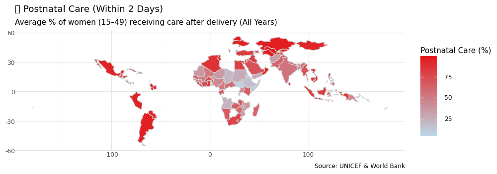

```python
# @title Default title text
from plotnine import *

map_plot = (
    ggplot(map_df.dropna(subset=["obs_value"])) +
    aes(map_id="country", fill="obs_value") +
    geom_map(color="lightgray") +
    scale_fill_gradient(low="#bdd7e7", high="#e31a1c", name="Postnatal Care (%)") +
    coord_fixed() +
    labs(
        title="🌍 Postnatal Care (Within 2 Days)",
        subtitle="Average % of women (15–49) receiving care after delivery (All Years)",
        caption="Source: UNICEF & World Bank"
    ) +
    theme_minimal() +
    theme(figure_size=(10, 24))  # 📐 Taller portrait map
)

map_plot.draw()
```

## Urgent Attention: Bottom 10 Countries with Lowest Postnatal Care

This chart highlights countries where maternal postnatal care is alarmingly low. It points to systemic challenges that need urgent international aid, policy reform, or healthcare infrastructure investment.

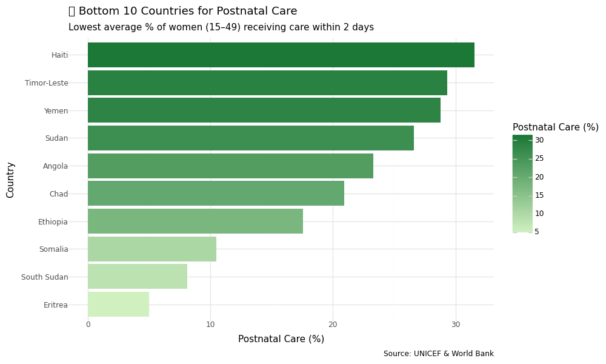

```python
# @title Default title text
from plotnine import *

bar_plot = (
    ggplot(df_bottom10, aes(x="reorder(country, obs_value)", y="obs_value", fill="obs_value")) +
    geom_col() +
    scale_fill_gradient(
        low="#d0f0c0",   # light mint (low value)
        high="#1b7837",  # dark green (high value)
        name="Postnatal Care (%)"
    ) +
    coord_flip() +
    labs(
        title="📉 Bottom 10 Countries for Postnatal Care",
        subtitle="Lowest average % of women (15–49) receiving care within 2 days",
        x="Country",
        y="Postnatal Care (%)",
        caption="Source: UNICEF & World Bank"
    ) +
    theme_minimal() +
    theme(figure_size=(10, 6))
)

bar_plot.draw()
```

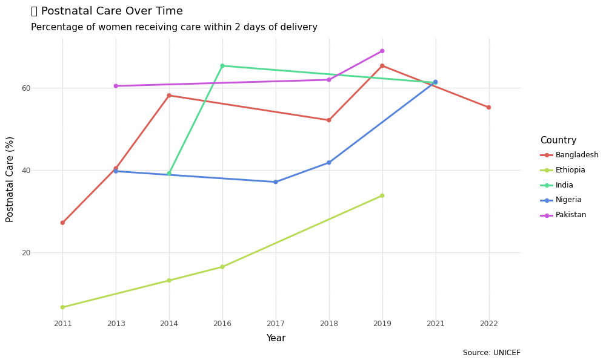

```python
# @title Default title text
line_plot = (
    ggplot(df_selected, aes(x="year", y="obs_value", color="country", group="country")) +
    geom_line(size=1.2) +
    geom_point(size=2) +
    labs(
        title="📈 Postnatal Care Over Time",
        subtitle="Percentage of women receiving care within 2 days of delivery",
        x="Year",
        y="Postnatal Care (%)",
        color="Country",
        caption="Source: UNICEF"
    ) +
    theme_minimal() +
    theme(figure_size=(10, 6))
)

line_plot.draw()
```

## The Wealth Gap: GDP per Capita vs Postnatal Care

This scatterplot reveals the relationship between national income and maternal care. A clear trend emerges—wealthier nations tend to have higher postnatal care coverage, indicating the influence of economic conditions on healthcare access.

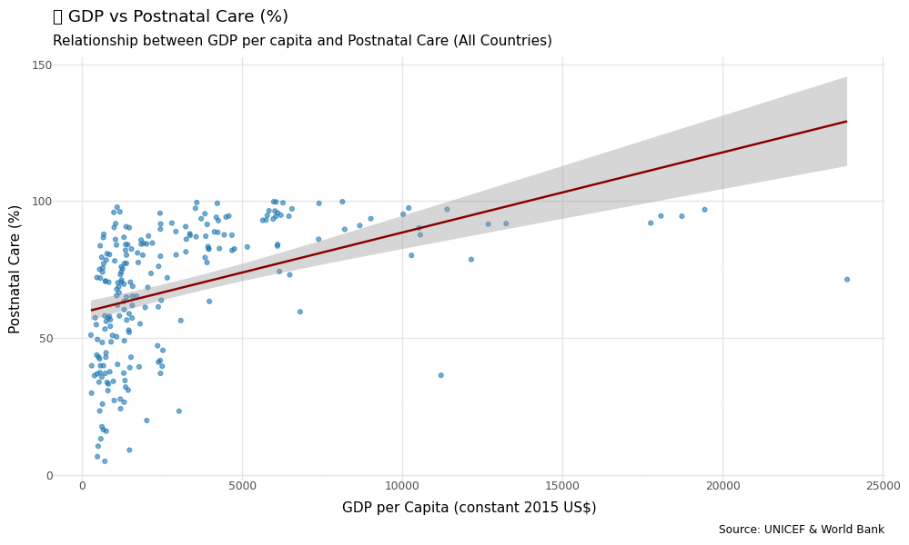

```python
# @title Default title text
from plotnine import *

scatter_plot = (
    ggplot(df_scatter, aes(x="gdp_per_capita", y="obs_value")) +
    geom_point(alpha=0.6, color="#1f78b4") +
    geom_smooth(method="lm", color="darkred", se=True) +
    labs(
        title="📉 GDP vs Postnatal Care (%)",
        subtitle="Relationship between GDP per capita and Postnatal Care (All Countries)",
        x="GDP per Capita (constant 2015 US$)",
        y="Postnatal Care (%)",
        caption="Source: UNICEF & World Bank"
    ) +
    theme_minimal() +
    theme(figure_size=(10, 6))
)

scatter_plot.draw()
```

## Infrastructure Matters: Hospital Beds vs Postnatal Care

This scatterplot explores how the availability of hospital beds per 1,000 people correlates with maternal postnatal care coverage.

A positive relationship emerges: as the number of hospital beds increases, so does the percentage of mothers receiving postnatal care. This suggests that infrastructure investment—particularly in healthcare facilities—plays a significant role in improving maternal health outcomes.

However, some countries with low bed availability still report high care percentages, pointing to possible success through community-based care or mobile health programs. These outliers highlight that while infrastructure is key, policy and program design also matter.

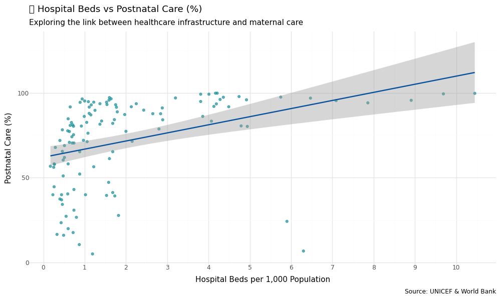

```python
# @title Default title text
from plotnine import *

hosp_plot = (
    ggplot(df_hosp, aes(x="hospital_beds", y="obs_value")) +
    geom_point(alpha=0.7, color="#1c9099") +  # brighter teal
    geom_smooth(method="lm", color="#08519c", se=True) +  # deep navy blue trend line
    labs(
        title="🏥 Hospital Beds vs Postnatal Care (%)",
        subtitle="Exploring the link between healthcare infrastructure and maternal care",
        x="Hospital Beds per 1,000 Population",
        y="Postnatal Care (%)",
        caption="Source: UNICEF & World Bank"
    ) +
    scale_x_continuous(breaks=range(0, 11)) +
    theme_minimal() +
    theme(figure_size=(10, 6))
)

hosp_plot.draw()
```

## Global Leaders: Top 10 Countries with Highest Postnatal Care Coverage

This bar chart showcases the countries that provide nearly universal postnatal care. These countries exemplify strong maternal healthcare systems and can offer best-practice models for others to follow.

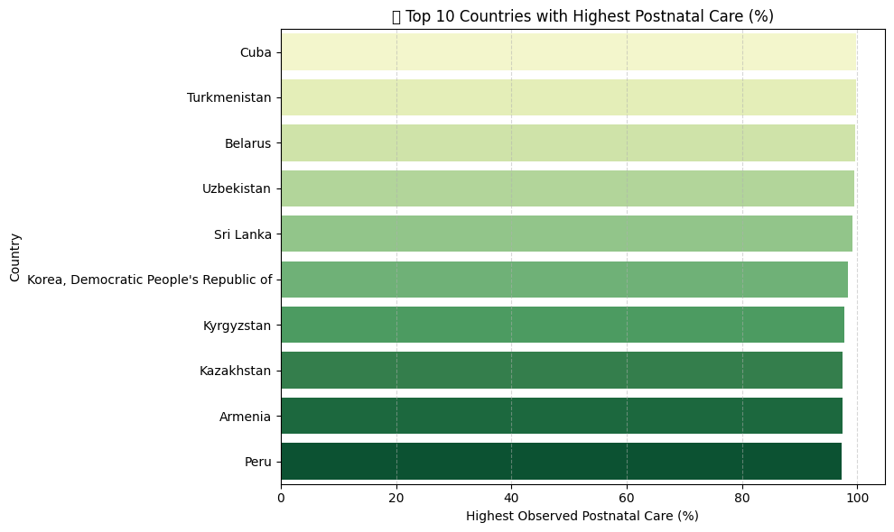

```python
# @title Default title text
import pandas as pd
import matplotlib.pyplot as plt
import seaborn as sns

# Step 1: Load the correct merged file
df = pd.read_csv("/content/merged_unicef_indicator2.csv")

# Step 2: Keep only relevant columns
df = df[["country", "year", "obs_value"]]

# Step 3: Get the highest postnatal care value per country
df_top = df.groupby("country", as_index=False)["obs_value"].max()

# Step 4: Take top 10 countries
df_top10 = df_top.sort_values("obs_value", ascending=False).head(10)

# Step 5: Plot it using seaborn with nice color
plt.figure(figsize=(10, 6))
sns.barplot(data=df_top10, x="obs_value", y="country", palette="YlGn")  # Green gradient
plt.xlabel("Highest Observed Postnatal Care (%)")
plt.ylabel("Country")
plt.title("🏆 Top 10 Countries with Highest Postnatal Care (%)")
plt.grid(axis='x', linestyle='--', alpha=0.5)
plt.tight_layout()
plt.show()
```

## Yearly Distribution of Postnatal Care (%): 2008–2023

This boxplot illustrates the distribution of postnatal care coverage across countries for each year between 2008 and 2023.

Each box represents the middle 50% of countries, while the lines (whiskers) show the overall spread. Outliers are shown as individual dots.

Key takeaways: - **Median values have generally increased**, reflecting global progress. - The **range of care levels remains wide**, especially in earlier years. - **Recent years show greater consistency**, suggesting more countries are aligning around higher care standards. - A sharp dip in 2023 may indicate incomplete data reporting or pandemic-related setbacks.

This visual highlights both encouraging progress and continued disparities in maternal health coverage worldwide.

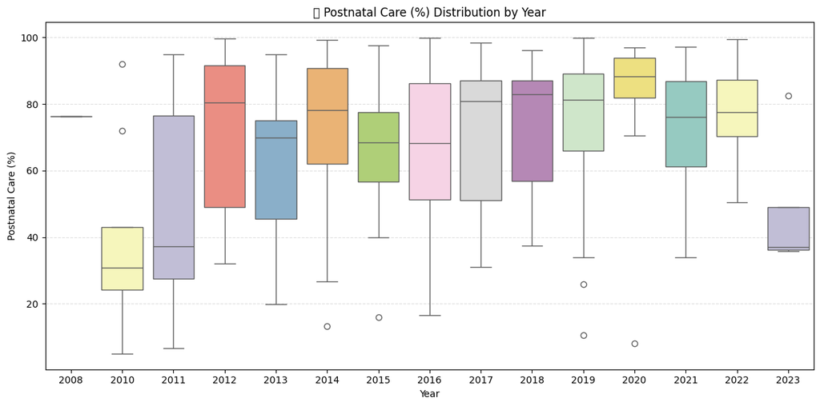

```python
# @title Default title text
import matplotlib.pyplot as plt
import seaborn as sns

# Drop rows with missing values in year or obs_value
df_box = df[["year", "obs_value"]].dropna()

plt.figure(figsize=(12, 6))
sns.boxplot(data=df_box, x="year", y="obs_value", palette="Set3")

# Style
plt.title("📦 Postnatal Care (%) Distribution by Year")
plt.xlabel("Year")
plt.ylabel("Postnatal Care (%)")
plt.grid(axis="y", linestyle="--", alpha=0.4)
plt.tight_layout()
plt.show()
```

# Conclusion

This analysis highlights both progress and persistent challenges in ensuring maternal health worldwide. Wealthier countries lead in postnatal care, while low-income nations often lag due to economic, political, and infrastructural barriers.

To close the gap: - Global cooperation is needed. - Investment in maternal health is vital. - Data transparency must be improved.

Ensuring that every mother receives adequate postnatal care is a shared responsibility—one that requires urgency, innovation, and equity.